# Slow–Fast Coupling_v4: Curie–Weiss Symptoms Under Context Dynamics

We study a slow–fast hybrid system in which a fast, Ising-like (Curie–Weiss) symptom layer is coupled to a slow contextual process with feedback and noise. Simulations illustrate how slow contextual differences can drive tipping or switching-like patterns in symptoms without changing the symptom-layer coupling.

Author

Affiliation

Kyuri Park

Computational Science Lab

Published

February 11, 2026

```r
library(dplyr)
library(tidyr)
library(purrr)
library(tibble)
library(ggplot2)
library(knitr)
library(kableExtra)
library(patchwork)

library(future)
library(furrr)


# If you want full reproducibility across parallel:
set.seed(1)

# One plan for the whole doc
plan(multisession, workers = max(1, parallel::detectCores() - 3))

source("R/utils_fastlayer.R")
source("R/utils_slowfast.R")
source("R/utils_plotting.R")
source("R/utils_diagnostics.R")
source("R/utils_gridsearch.R")
```

# 1. Motivation

Mental health symptoms fluctuate on fast time scales (hours–days), while socio-economic pressures (e.g., financial precarity, discrimination, workload) change more slowly (months–years). Standard symptom-network models often:

- treat symptoms as a *closed* system, and
- interpret group differences in symptom dynamics as *internal* differences in network structure.

Here we explicitly couple:

- a **fast 0/1 Curie–Weiss symptom layer** (binary symptoms with mean-field interaction),
- a **slow precarity variable** $P_t$ that drifts gradually, and
- **feedback** from symptoms back into precarity.

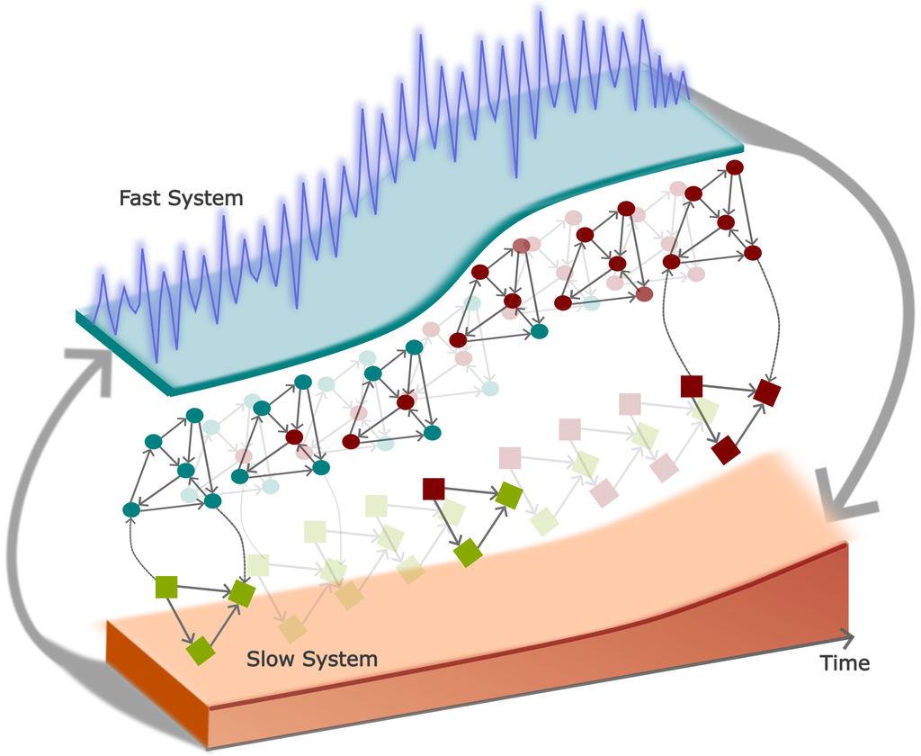

We show how **group differences in symptom trajectories** can arise purely from:

- different **precarity baselines**, and
- different **feedback strengths**,

with *identical* fast-layer parameters.

# 2. Fast layer: 0/1 Curie–Weiss symptom dynamics

We use spins

$$s_i \in \{0,1\},
\qquad
m = \frac{1}{N}\sum_i s_i \in [0,1].$$
Here, $m$ is the fraction of active symptoms (a fast, summary “symptom load”).

### Mean-field input (“field”)

The mean-field “field” is

$$H = J(m - \tfrac{1}{2}) + h_0 + \gamma_P P.$$
Each symptom feels the same global input, $H$.

- J: within-layer coupling (symptom reinforcement). If many symptoms are active ($m>0.5$), the coupling term pushes activation higher; if few are active, it pushes lower.
- $h_0$: baseline bias (overall tendency toward on/off).
- $\gamma_P$: context modulation—external context $P$ shifts the entire layer toward more or fewer active symptoms.

### Stochastic activation rule

We update spins with a logistic rule:

$$\Pr(s_i=1 \mid m, P)=\sigma(\beta H), \qquad
\sigma(x)=\frac{1}{1+e^{-x}}$$

- $\beta$: *sensitivity* (how sharply symptoms respond to the input $H$). Large $\beta$ makes the layer more “all-or-none”; small $\beta$ makes it smoother.

**Potential QnA**

*Q. What is Curie–Weiss?*

Curie–Weiss is the mean-field Ising model: every node “interacts with everyone else equally,” so the whole system can be summarized by the average activity $m$ rather than a full network. Curie–Weiss is the simplest possible interacting-symptom model: instead of a detailed network, every symptom feels the same average influence from all the others.

*Q. What does J mean here?*

“$J$ is the strength of mutual reinforcement: how much the probability a symptom is ‘on’ increases when the overall symptom load $m$ is high.”

*Q. Why not a 10-node symptom network?*

“We’re not trying to reproduce a particular 10-item network. Curie–Weiss is a mean-field stand-in for a generic reinforcing symptom layer. Using a larger $N$ just reduces finite-size noise so the regime structure (monostable vs bistable) is visually clean.”

### Key regime condition: bistability

When the effective reinforcement $\beta J$ is strong enough, the mean-field fixed point can become **bistable**:

- one stable state with **low** symptom activation $(m\approx 0)$,
- one stable state with **high** activation $(m\approx 1)$.

For the 0/1 Curie–Weiss model, bistability occurs when:

$$\beta J > 4$$

**Interpretation:** with strong coupling, the fast layer can support two persistent symptom “modes” under the same context $P$. Which mode the system occupies can depend on history and (in finite systems) noise—this is the structural basis for threshold effects, hysteresis, and regime shifts once we couple to the slow context dynamics.

**Why $\beta J > 4$**

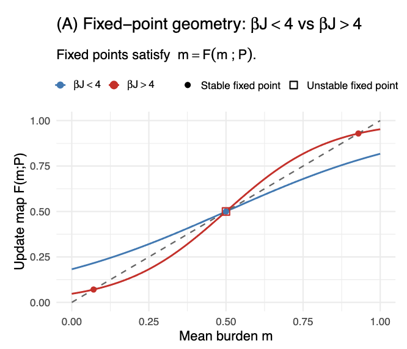

#### Bistability criterion in 0/1 Curie–Weiss

$$m = \sigma\left(\beta\left[J(m-\tfrac12)+h_0+\gamma_P P\right]\right)$$

- Fixed points are **intersections** of:
  - $y=m$ (straight line, slope $1$)
  - $y=\sigma(\beta H(m))$ (sigmoid in $m$)
- Multiple fixed points require the sigmoid to be **steeper than the line** near its midpoint.

**Slope check:**
$$\frac{d}{dm}\sigma(\beta H)=\beta J\sigma(\beta H)\big(1-\sigma(\beta H)\big)$$

- The logistic term is maximal at $\sigma=1/2$: $\max[\sigma(1-\sigma)]=1/4$

So the **maximum possible slope** is:

$$\max \frac{d}{dm}\sigma(\beta H) = \frac{\beta J}{4}$$

**Bistability condition:**
$$\frac{\beta J}{4} > 1 \Rightarrow \beta J > 4$$

**Interpretation:** when $\beta J>4$, the fast layer supports **two stable modes** (low vs high $m$) for the *same* context $P$. Which mode you observe depends on **history** (and for finite $N$, occasional noise-driven switching).

**Derivative of update map $F(m;P)$**

Define the fixed-point map
$$F(m;P)=\sigma\left(\beta\left[J(m-\tfrac12)+h_0+\gamma_P P\right]\right).$$

#### 1) Name the inside (“chain rule setup”)

Let
$$u(m)=\beta\left[J(m-\tfrac12)+h_0+\gamma_P P\right].$$

Then
$$F(m;P)=\sigma(u(m)).$$

#### 2) Derivative of the logistic

For $\sigma(x)=\frac{1}{1+e^{-x}}$,

$$\sigma'(x)=\sigma(x)\big(1-\sigma(x)\big).$$

So by chain rule,
$$\frac{dF}{dm}=\sigma'(u(m))\cdot u'(m).$$

#### 3) Derivative of the inside $u(m)$

$$u'(m)=\beta \cdot \frac{d}{dm}\left[J(m-\tfrac12)+h_0+\gamma_P P\right]
=\beta \cdot J,$$
because $h_0$ and $P$ are constants with respect to $m$.

#### 4) Combine

$$\frac{dF}{dm}
=\sigma'(u(m))\cdot (\beta J)
=(\beta J)\sigma(u(m))\big(1-\sigma(u(m))\big).$$

#### 5) Put it back in original symbols

Since $\sigma(u(m)) = F(m;P)$, you can write

$$\boxed{\frac{d}{dm}\sigma\left(\beta\left[J(m-\tfrac12)+h_0+\gamma_P P\right]\right)
= \beta J p(1-p);}$$

where
$$p = \sigma\left(\beta\left[J(m-\tfrac12)+h_0+\gamma_P P\right]\right).$$

# 3. Slow layer: external context dynamics

1. **Mean reversion** toward a baseline level $P_{\text{base}}$ (can differ across groups)
2. **Feedback from symptoms** (via a slow symptom trace $m_{\text{slow}})$
3. **Random fluctuations** (Gaussian noise)
4. **Optional discrete shocks** (rare jump events)

### Context update equation (Euler–Maruyama)

We then update $P_t$ with:

$$P_{t+1} = P_t
+\Big[-\kappa(P_t-P_{\text{base}})+b(m_{\text{slow},t}-m_*)\Big]dt
+\sigma_P \sqrt{dt}\epsilon_t + J_t,
\qquad \epsilon_t\sim \mathcal{N}(0,1).$$

Breakdown of terms:

#### 1) Mean reversion (OU drift)

$$-\kappa(P_t-P_{\text{base}})$$

- $\kappa>0$ pulls context back to baseline.
- Larger $\kappa$ = faster reversion (context is “stiff,” resists deviation).
- Smaller $\kappa$ = slower reversion (context drifts more freely).

This is the standard Ornstein–Uhlenbeck (OU) mechanism: context is not a random walk; it has a preferred level.

#### 2) Symptom → context feedback

$$b(m_{\text{slow},t}-m_*)$$

- $b$ is feedback strength.
- $m_*$ is the reference “setpoint” symptom level:
  - if $m_{\text{slow}} > m_*$, feedback pushes $P$ **up**
  - if $m_{\text{slow}} < m_*$, feedback pushes $P$ **down**

Interpretation: sustained symptom burden can gradually worsen context (or, if below setpoint, allow recovery), depending on sign/magnitude of $b$.

**Why introduce $m_{\text{slow}}$**

The fast symptom mean $m_t$ can fluctuate quickly from moment to moment. If context responded instantly to $m_t$, the slow variable wouldn’t be “slow.” So we define a smoothed symptom signal that tracks sustained symptom burden rather than short-lived spikes:

$$m_{\text{slow},t+1}=m_{\text{slow},t}+\lambda_m(m_t-m_{\text{slow},t})$$

- This is an exponentially weighted moving average (*EWMA*).
- $\lambda_m$ controls the time scale:
  - small $\lambda_m$ → strong smoothing / long memory (context reacts only to persistent changes)
  - large $\lambda_m$ → tracks $m_t$ more quickly / short memory (context reacts more quickly).

Interpretation: $m_{\text{slow}}$ is the symptom signal that external context “sees” (e.g., accumulated strain, sustained burden), not moment-to-moment noise. If symptoms spike for a day and then drop, we don’t want context to react strongly. But if symptoms stay elevated for weeks, then context should shift. $m_{\text{slow}}$ captures that sustained burden.

#### 3) Stochastic perturbations

$$\sigma_P \sqrt{dt},\epsilon_t$$

- $\sigma_P$ is the amplitude of random contextual shocks.
- The $\sqrt{dt}$ scaling is standard for SDE discretization: it keeps noise behavior consistent when you change $dt$.

#### 4) Optional discrete shocks $J_t$

To allow rare acute events (sudden stressors) that cause discontinuous changes in context, we add an optional jump term $J_t$ to the slow context update. Most of the time $J_t=0$. When a shock occurs, $J_t \neq 0$ and its magnitude is drawn from a “shock size” distribution.

A convenient representation is:

$$J_t = I_t \cdot A_t,
\qquad I_t\in{0,1},\quad A_t\sim \mathcal{N}(\mu_J,\sigma_J^2).$$

- $I_t$ indicates whether a shock happens at time $t$.
- $A_t$ is the shock magnitude (positive = adverse shock; negative = relief shock, if allowed).

##### Two shock mechanisms (both optional)

You can include either, both, or neither.

###### (A) Symptom-triggered shocks (distress-triggered acute events)

Idea: “If symptoms stay high long enough, the chance of an acute hit increases.”

We introduce a latent **strain** variable that represents *accumulated overload*. Strain builds up when the smoothed symptom level $m_{\text{slow},t}$ stays above a critical threshold $m_{\text{crit}}$, and it relaxes back down when symptoms are below that threshold:

$$\text{strain}_{t+1}=(1-\rho)\text{strain}_t+\rho\max\bigl(0, m_{\text{slow},t}-m_{\text{crit}}\bigr).$$

- If $m_{\text{slow},t}\le m_{\text{crit}}$: the max-term is 0, so strain **decays** (by factor $1-\rho$).
- If $m_{\text{slow},t}> m_{\text{crit}}$: strain **increases**, and it increases more when symptoms are *further above* the threshold.
- $\rho\in(0,1)$ sets how quickly strain responds (higher () = faster build/decay).

We then make the probability of an endogenous shock increase with strain by converting strain into a **time-varying hazard rate**:

$$\lambda_t=\min\bigl(\lambda_0+\lambda_1\text{strain}_t,\lambda_{\text{cap}}\bigr),
\qquad
I_t\sim \text{Bernoulli}\left(1-e^{-\lambda_t dt}\right).$$

- $\lambda_0$: baseline hazard (can be zero).
- $\lambda_1$: how strongly hazard grows with strain.
- $\lambda_{\text{cap}}$: caps the hazard so shocks don’t become nearly deterministic.
- The term $1-e^{-\lambda_t dt}$ is the per-step probability corresponding to a Poisson hazard $\lambda_t$.

When $I_t=1$, a shock occurs and we draw its magnitude $A_t$ (e.g. $A_t\sim\mathcal N(\mu,\sigma^2)$), and add it to the context update via $J_t=I_tA_t$.

Finally, to avoid “clock-like” repeated shocks, we impose a **refractory period** (cooldown) after a shock (optionally randomized), and we **reduce strain** immediately after a shock (e.g. multiply strain by a factor $<1$). Together these create more realistic, irregular shock timing.

*Interpretation*. Strain is a *soft persistence* measure: it grows under sustained high symptoms and fades gradually when symptoms ease. As strain rises, the chance of an acute adverse event rises as well—capturing a feedback loop where prolonged burden makes disruptive events more likely.

###### (B) Exogenous shocks (independent life events), person-specific rates

Idea: shocks can occur independently of symptoms, and individuals can differ in baseline exposure.

For individual $i$, draw a personal shock rate $p_{0,i}$ (or set it by group). Then

$$I^{(X)}_{i,t} \sim \text{Bernoulli}(p_{0,i},dt),
\qquad A^{(X)}_{i,t}\sim \mathcal N(\mu_X,\sigma_X^2),$$

and $J^{(X)}_{i,t}=I^{(X)}_{i,t}A^{(X)}_{i,t}$.

*Interpretation*. Stable heterogeneity in exposure to acute events (e.g., job insecurity, unsafe environment), not necessarily mediated by symptoms.

### Combine them

Total jump is the sum:

$$J_t = J^{(D)}_t + J^{(X)}_t.$$

Setting $p_D=0$ disables symptom-triggered shocks; setting $p_{0,i}=0$ disables exogenous shocks.

**Parameter intuition (matches `simulate_slowfast_cw01_v2()`)**

### Slow context (OU + feedback + noise)

- **$\kappa$** (`kappa`): mean reversion strength of context toward the baseline $P_{\text{base}}$. Larger $\kappa$ = stiffer / faster return.
- **$\sigma_P$** (`sigmaP`, and internally `sigma0` when volatility modulation is used): baseline diffusion scale of contextual noise. The stochastic term is $\sigma_t\sqrt{dt}\varepsilon_t$.
- **$b$** (`b`): symptom $\rightarrow$ context feedback strength. Larger $b$ makes sustained symptoms shift $P_t$ more strongly.
- **$m_*$** (`m_star`): feedback setpoint. If $m_{\text{slow}} > m_*$, feedback pushes $P$ upward; if $m_{\text{slow}} < m_*$, it pulls $P$ downward.
- **$\lambda_m$** (`lambda_m`): EWMA rate for the slow symptom trace $m_{\text{slow}}$. Smaller $\lambda_m$ = stronger smoothing / longer memory.

### Optional volatility modulation

- **$\sigma_0$** (`sigma0`): baseline volatility used when modulation is active (defaults to $\sigma_P$ if not provided).
- **$\sigma_1$** (`sigma1`): how strongly volatility increases with symptoms.
- **$m_{\text{vol,th}}$** (`m_vol_th`) and **$m_{\text{vol,sc}}$** (`m_vol_sc`): threshold and scale for the logistic gating $g_{\text{vol}}(m_{\text{slow}})$ that increases $\sigma_t$ when symptoms are high.

### Exogenous shocks (independent jump events)

Exogenous shocks are implemented as a Poisson jump process with intensity $\lambda_{\text{exo}}$ per unit time. In each time step of size $dt$, the per-step probability is
$$p_{\text{exo}} = 1 - e^{-\lambda_{\text{exo}},dt}.$$

- **$\lambda_{\text{exo}}$** (`lambda_exo`): exogenous shock intensity (per unit time). *Set $\lambda_{\text{exo}}=0$ or `shock_mode="none"/"endo"` to disable exogenous shocks.*
  - **Gate function** (`exo_gate_fun(P,t)`): optional on/off control for when exogenous shocks are allowed (e.g., only in certain context ranges or times).
- **($\mu_{\text{exo}},\sigma_{\text{exo}}$)** (`shock_mu_exo`, `shock_sd_exo`): exogenous shock magnitude distribution; when a shock occurs,

$$A^{(\text{exo})}_t \sim \mathcal N(\mu_{\text{exo}}, \sigma_{\text{exo}}^2),
\qquad J^{(\text{exo})}_t = A^{(\text{exo})}_t$$

(or fixed $A=\mu_{\text{exo}}$ if `shock_sd_exo=0`). * **Refractory / cooldown** (`cooldown_exo`): after an exogenous shock, additional exogenous shocks are suppressed for this many steps (prevents unrealistically frequent events).

### Endogenous shocks (symptom-triggered via strain)

Endogenous shocks are driven by a latent **strain** variable that accumulates when symptoms stay above a threshold and relaxes otherwise:

$$\text{strain}_{t+1}=(1-\rho),\text{strain}_t+\rho\max(0, m_{\text{slow},t}-m_{\text{crit}}).$$

Strain is converted into a time-varying **hazard** (intensity per unit time):

$$\lambda_t=\min(\lambda_0+\lambda_1\text{strain}_t,\lambda_{\text{cap}}),
\qquad
p_{\text{endo},t}=1-e^{-\lambda_t,dt},
\qquad
I_t\sim \mathrm{Bernoulli}(p_{\text{endo},t}).$$

- **$\rho$** (`rho_strain`): strain update rate (memory). Small $\rho$ = slow build/decay; large $\rho$ = fast response.
- **$m_{\text{crit}}$** (`m_crit`): symptom threshold above which strain accumulates (“distress counts”).
- **$\lambda_0$** (`lambda0`): baseline endogenous hazard (can be 0).
- **$\lambda_1$** (`lambda1`): how strongly hazard increases with strain.
- **$\lambda_{\text{cap}}$** (`lambda_cap`): caps hazard so shocks do not become near-deterministic.
- **$(\mu_{\text{endo}},\sigma_{\text{endo}})$** (`shock_mu_endo`, `shock_sd_endo`): endogenous shock size distribution; when $I_t=1$,

$$A^{(\text{endo})}_t \sim \mathcal N(\mu_{\text{endo}}, \sigma_{\text{endo}}^2),
\qquad J^{(\text{endo})}_t = A^{(\text{endo})}_t$$

(or fixed $A=\mu_{\text{endo}}$ if `shock_sd_endo=0`). * **Refractory / cooldown** (`cooldown_endo`): after an endogenous shock, additional endogenous shocks are suppressed for a number of steps. * **Cooldown jitter** (`cooldown_jitter`): randomizes the refractory length by $\pm$ a fraction to avoid clock-like periodic shocks. * **Strain drop (post-shock relief)** (`strain_drop`): after an endogenous shock, strain is multiplied by this factor (e.g., $<1$) so hazard temporarily decreases.

### How shocks enter the context update (both types)

At each step, context is updated by drift + diffusion + jumps:
$$P_{t+1}=P_t + dt\Big[-\kappa(P_t-P_{\text{base}})+b(m_{\text{slow},t}-m_*)\Big]
+\sigma_t\sqrt{dt}\varepsilon_t
+J^{(\text{exo})}_t + J^{(\text{endo})}_t .$$

- `shock_mode="none"` disables all jumps.
- `shock_mode="exo"` enables only $J^{(\text{exo})}$.
- `shock_mode="endo"` enables only $J^{(\text{endo})}$.
- `shock_mode="both"` enables both and adds them.

# 4. Fast-layer equilibrium structure and fold thresholds

For a fixed context value $P$, the mean-field Curie–Weiss layer relaxes toward equilibrium levels $m^*(P)$ that satisfy

$$m = \sigma\left(\beta\left[J(m-\tfrac12)+h_0+\gamma_P P\right]\right).$$

We compute these equilibria across a range of $P$ and plot $m^*(P)$ as a **bifurcation diagram**:

- **Solid curves:** stable equilibria (attractors)
- **Dashed curve:** unstable equilibrium (separator)
- **Grey band:** range of $P$ where **two stable equilibria coexist** (bistability)

### Fold thresholds

The **folds** $P_{\text{low fold}}$ and $P_{\text{high fold}}$ are the two edges of the bistable region:

- crossing a fold means one stable branch disappears,
- the system must **jump** to the remaining stable branch.

**Why this matters:** when context $P_t$ changes slowly, folds create **threshold-like jumps** and **hysteresis**.

```r
# ------------------------------------------------------------
# Example: bistable-capable fast layer used in Scenarios B and C
#
# Choose beta and J such that beta*J > 4 (bistability possible for some P):
#   beta = 2, J = 3  -> beta*J = 6 > 4
# Then compute the bifurcation diagram m*(P) over a range of P.
# ------------------------------------------------------------

beta_BC   <- 2.0
J_BC      <- 3.0    # beta*J = 6 (> 4) => bistable-capable regime
h0_BC     <- 0.0
gammaP_BC <- 1.0

# Grid of context values over which we compute equilibria
P_grid_BC <- seq(-2, 2, length.out = 400)

# Full table of equilibria: columns (P, m, stable)
bf_BC <- cw01_bifurcation_curve(P_grid_BC, beta_BC, J_BC, h0_BC, gammaP_BC)

# ------------------------------------------------------------
# Summarize, for each P:
#   - how many stable equilibria exist (n_stable)
#   - the lowest/highest stable equilibria (m_low, m_high)
# If n_stable == 2, the system is bistable at that P.
# ------------------------------------------------------------

stab_by_P <- bf_BC %>%
  filter(stable) %>%
  group_by(P) %>%
  summarise(
    n_stable = n(),
    m_low  = min(m),
    m_high = max(m),
    .groups = "drop"
  )

# Extract the P-range where there are TWO stable equilibria (bistable window)
bistable_window <- stab_by_P %>% filter(n_stable == 2)

# Fold thresholds = the edges of the bistable window
# (where one stable branch disappears)
if (nrow(bistable_window) > 0) {
  P_low_fold  <- min(bistable_window$P)
  P_high_fold <- max(bistable_window$P)
} else {
  P_low_fold  <- NA_real_
  P_high_fold <- NA_real_
}

cat("Bistable P-window: [", round(P_low_fold, 3), ", ", round(P_high_fold, 3), "]\n", sep = "")
```

```
Bistable P-window: [-0.206, 0.206]
```

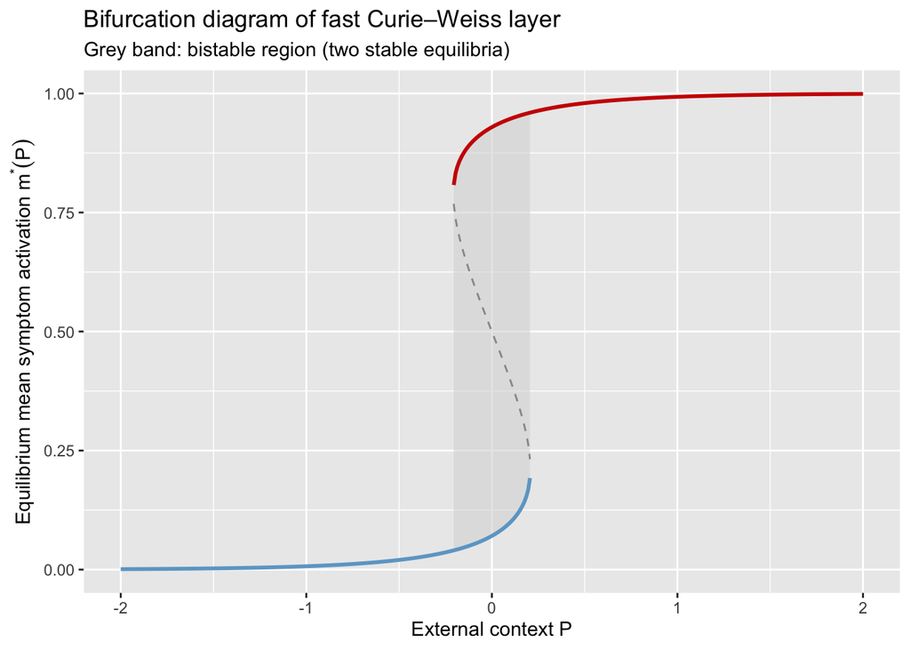

```r
# ------------------------------------------------------------
# Plot:
#   - Grey ribbon: region between stable low/high branches when bistable
#   - Solid curves: stable equilibria
#   - Dashed curve: unstable equilibria (middle branch when bistable)
# ------------------------------------------------------------

ggplot() +
  { if (nrow(bistable_window) > 0)
      geom_ribbon(
        data = bistable_window,
        aes(x = P, ymin = m_low, ymax = m_high),
        fill = "grey85", alpha = 0.6
      )
  } +
  geom_line(
    data = bf_BC %>% filter(!stable),
    aes(P, m),
    linetype = "dashed", colour = "grey60"
  ) +
  geom_line(
    data = bf_BC %>% filter(stable, m < 0.5),
    aes(P, m),
    linewidth = 1.0,
    color = "skyblue3"
  ) +
  geom_line(
    data = bf_BC %>% filter(stable, m >= 0.5),
    aes(P, m),
    linewidth = 1.0,
    color = "red3"

  ) +
  labs(
    title    = "Bifurcation diagram of fast Curie–Weiss layer",
    subtitle = "Grey band: bistable region (two stable equilibria)",
    x = expression("External context " * P),
    y = expression("Equilibrium mean symptom activation " * m^"*"*(P))
  )
```

# 5. Scenario map

## What is held constant vs what changes

**Within any single scenario (A / B / C1 / C2):**

**Across scenarios: what we intentionally manipulate**

- We switch the fast-layer regime by moving between $\beta J<4$ (monostable) and $\beta J>4$ (bistable-capable).
- We toggle **feedback** by setting $b=0$ (off) versus $b>0$ (on).
- We adjust $\kappa$ (mean reversion) and $\sigma_P$ (noise) to tune how tightly $P_t$ tracks baseline and how easily trajectories cross between basins.

## Optional modifiers

We optionally allow the slow context process to include:

- **State-dependent volatility:** $\sigma_t = \sigma_0(1+\sigma_1 g(m_{\text{slow}}))$
- **Discrete shocks (jumps):** $P_{t+1} \leftarrow P_{t+1} + J_t$, where $J_t$ can be:
  - **exogenous** (life events; person-specific rate), and/or
  - **endogenous** (distress-triggered; hazard increases after sustained high $m_{\text{slow}}$).

These modifiers do *not* change the symptom coupling $J$; they change the *context process*.

**Each scenario (what it isolates)**

##### **A** ($\beta J<4$): smooth context → smooth symptoms

**Setup:** Fast layer has a *single* stable equilibrium $m^*(P)$ for all $P$. Two groups differ only in constant $P_{\text{base}}$.  
**Demonstration:** shifting baseline context shifts $m$ **smoothly** (no thresholds, no hysteresis).

##### **B** ($\beta J>4$, $b=0$): hysteresis under a slow context ramp

**Setup:** Fast layer is bistable-capable. Baseline is ramped $P_{\text{base}}(t)$ up then down; feedback off.  
**Demonstration:** **path dependence** — on the way up the trajectory stays on the low branch until the *upper threshold*; on the way down it stays high until the *lower threshold*, producing a hysteresis loop in $m$ vs $P$.

##### **C** ($\beta J>4$, $b>0$): feedback makes context endogenous

**Setup:** Same bistable-capable fast layer, but symptoms push context via feedback:
$$P_{t+1}=P_t + dt\{-\kappa(P_t-P_{\text{base}}) + b(m_{\text{slow},t}-m_*)\} + \sigma_P\sqrt{dt}\,\epsilon_t.$$
**Demonstration:** depending on $(b,\kappa,\sigma_P,m_*)$, trajectories either:

- **C1:** get captured in the high basin (tipping-like persistence), or
- **C2:** keep switching between basins (metastable switching).

**Where shocks enter (kept concise)**

```r
#| label: scenario-params-table-compact
#| echo: false
#| eval: true


param_tbl_compact <- tribble(
  ~Scenario, ~Regime, ~`βJ`, ~`γ_P`, ~`κ`, ~`b`, ~`σ_P`, ~`m_*`, ~`P_base`, ~`Modifier`, ~`Key point`,
  "A",   "monostable",        2.5, 0.4, 0.30, 0.20, 0.10, 0.10, "[-0.80, 0.80]",  "none",         "Smooth mean shift",
  "B",   "bistable-capable",  6.0, 1.0, 0.15, 0.00, 0.02, 0.30, "ramp↑then↓",      "none",         "Hysteresis loop",
  "C1",  "bistable-capable",  6.0, 1.0, 0.10, 0.28, 0.06, 0.12, "[-1.006, 0.000]", "none",         "Capture (long dwell)",
  "C2",  "bistable-capable",  6.0, 1.0, 0.38, 0.16, 0.20, 0.25, "[-1.006, 0.000]", "none",         "Switching (many flips)",
  "C2-S","bistable-capable",  6.0, 1.0, 0.38, 0.16, 0.20, 0.25, "[-1.006, 0.000]", "shocks on",    "Event-triggered switching"
)

kable(
  param_tbl_compact,
  digits = 3,
  align  = c("l","c","r","r","r","r","r","r","c","l"),
  # caption = "Scenario parameters."
) |>
  kable_styling(
    font_size = 13,
    full_width = TRUE,
    position = "center",
    bootstrap_options = c("responsive", "hover", "condensed", "striped")
  ) |>
  row_spec(0, bold = TRUE) |>
  column_spec(1, bold = TRUE, width = "4.5em") |>
  column_spec(2, width = "4em") |>
  column_spec(9, width = "7.5em") |>
  column_spec(10, width = "13em") |>
  footnote(
    general = "Shared unless noted: n_nodes=100;  λ_m=0.001;  sweeps=40;  h0=0.",
    general_title = "Note. ",
    footnote_as_chunk = TRUE,
    threeparttable = TRUE,
    fixed_small_size= TRUE
  )
```

[output not shown]

Note. Shared unless noted: n_nodes=100; λ_m=0.001; sweeps=40; h0=0.

Scenario parameters.

**Why parameter differs**

##### 1) $\beta J$: 2.5 in A vs 6.0 in B/C

- **This is the only parameter that changes the *qualitative* phase portrait of the fast layer.**
- **A** is explicitly the *control case*: $\beta J<4\Rightarrow$ one stable equilibrium $m^*(P)$ for each $P$.
- **B/C** need bistability (two stable branches + folds): $\beta J>4$.

So $\beta J$ differs because A vs B/C are different fast-layer regimes by definition, not for convenience.

##### 2) $\gamma_P$: 0.4 in A vs 1.0 in B/C

- $\gamma_P$ sets the **gain** from context $P$ into the fast-layer field $H$.
- In **B** (hysteresis), the whole point is to *sweep through the bistable window* as $P_{\text{base}}(t)$ ramps. Using $\gamma_P=1$ makes the ramp traverse the bifurcation region cleanly without needing extreme $P$ values.
- In **A**, we don’t need to “hit folds” (there aren’t any). A smaller $\gamma_P$ keeps the mapping smooth and avoids saturating (m) near 0 or 1, so you get an interpretable “smooth mean shift”.

So $\gamma_P$ is chosen to keep $P$ in a comparable, readable range while achieving the intended effect.

##### 3) $b$: 0 in B, positive in A/C

- **B** is defined as “no feedback”: $b=0$. That’s essential to show **pure exogenous hysteresis**.
- **C** is defined as “feedback on”: $b>0$. That’s the whole mechanism (context becomes endogenous).
- **A** can have $b>0$ without creating tipping, because the fast layer has no competing basins; feedback only shifts the single equilibrium smoothly. Keeping (b>0) in A is defensible because it shows: *even with feedback, monostability prevents regime shifts.*

##### 4) $\kappa$: 0.30 (A), 0.15 (B), 0.10/0.38 (C1/C2)

Think of $\kappa$ as the **stiffness** of context around its baseline.

- **A (0.30):** moderate stiffness so $P_t$ stays near its baseline levels, producing stable separation between groups.
- **B (0.15):** must be **low enough** that $P_t$ can actually track the ramp $P_{\text{base}}(t)$ (otherwise the ramp is “canceled” by strong reversion).
- **C1 vs C2:** $\kappa$ is part of what controls whether feedback produces **capture** or **wandering**:
  - **C1 (0.10):** weaker pull-back makes it easier for feedback to shift $P$ and hold the system in a high regime (capture).
  - **C2 (0.38):** stronger pull-back resists drift, so even with feedback the system doesn’t lock—switching becomes easier when combined with high noise.

So $\kappa$ is not “tuned”; it is the knob for *how responsive context is* relative to baseline vs feedback.

##### 5) $\sigma_P$: 0.10 (A), 0.02 (B), 0.06 (C1), 0.20 (C2)

Noise is the knob for **how often you see stochastic transitions** (when transitions are possible).

- **A:** noise just adds realistic variability around the single equilibrium. It doesn’t create regime switching because there is only one basin.
- **B (0.02):** you intentionally want a **clean hysteresis loop** driven by the ramp, not noise-driven hopping—so keep (_P) low.
- **C1 (0.06):** moderate noise, but not enough to prevent capture once feedback pushes into the high regime.
- **C2 (0.20):** high noise is essential for **metastable switching**; otherwise the system would just settle.

So $\sigma_P$ is set to either suppress switching (B), allow capture (C1), or promote switching (C2).

##### 6) $m_*$: 0.10 (A), 0.30 (B), 0.12/0.25 (C1/C2)

$m_*$ is the **reference symptom level** for the feedback term $b(m_{\text{slow}}-m_*)$. It determines the *direction* and *baseline strength* of feedback.

- In **B**, $b=0$ so $m_*$ is irrelevant (kept at a conventional value).
- In **C**, $m_*$ matters because it controls how easily feedback “turns on”:
  - **C1:** lower $m_*$ means feedback becomes positive already at relatively modest symptom levels, helping capture.
  - **C2:** higher $m_*$ reduces net upward drift except when symptoms are high, contributing to weaker net feedback and more switching.

In **A**, $m_*$ just sets where feedback pushes $P$ around its baseline; with one basin it remains smooth.

## *Scenario A*: monostable fast layer → smooth group differences

**Goal:** establish the baseline case where the fast symptom layer has a single stable equilibrium for every context level $P$. So if two groups differ only in their baseline context $P_{\text{base}}$, their symptom means differ smoothly —no abrupt transitions, no path dependence.

**Mechanism:** when $\beta J < 4$, the mean-field update map has only one stable fixed point $m^*(P)$. Even if context has feedback $b>0$, the fast layer cannot “choose between basins”, because there are no competing basins; so shifting $P$ shifts $m^*(P)$ continuously.

```r
# ---------------------------
# Scenario A: monostable regime (βJ < 4)
# ---------------------------

scen_A <- list(
  name = "A",
  burn_in = 500,
  T_steps = 6000,
  n_rep = 30,
  seed_base = 1000,
  groups = tibble::tibble(
    group = c("Low baseline context", "High baseline context"),
    P_base = c(-0.8, 0.8)
  ),
  par_fast = list(
    n_nodes = 100,
    sweeps  = 40,
    beta    = 1.0,
    J       = 2.5,     # βJ = 2.5 < 4  => monostable
    h0      = 0.0,
    gammaP  = 0.4
  ),
  par_slow = list(
    dt       = 0.02,
    kappa    = 0.30,
    b        = 0.20,
    m_star   = 0.10,
    sigmaP   = 0.10,
    lambda_m = 0.001,
    shock_mode = "none"  # make explicit
  )
)


# res_A <- run_scenario_diagnostics_v2(
#   scenario_name = "A (βJ<4, single equilibrium)",
#   par_fast = scen_A$par_fast,
#   par_slow = scen_A$par_slow,
#   P_bases  = scen_A$groups$P_base,
#   labels   = scen_A$groups$group,
#   T_steps  = scen_A$T_steps,
#   n_rep    = scen_A$n_rep,
#   seed_base = scen_A$seed_base,
#   burn_in  = scen_A$burn_in
# )
# saveRDS(res_A, "res/res_A_v3.rds") # nrep=30, and use run_scenario_diagnostics_v2
# saveRDS(res_A, "res/res_A_v2.rds") # sweeps =40 and ho = 0

res_A <- readRDS("res/res_A_v3.rds")
```

```r
ms_A_talk <- res_A$metrics_summary |>
  dplyr::transmute(
    Group             = group,
    `Mean context  E[P_t]`   = round(mean_P, 3),
    `Mean symptoms  E[m_t]`  = round(mean_m, 3),
    `Pr(m_t > 0.5)`          = round(frac_high_abs, 3),
    `Switches (branch)`      = round(n_switch, 1)
  )


kable(ms_A_talk, align = "lrrrr",
      caption = "Scenario A summary (monostable fast layer: no branch switching).") |>
  kable_styling(full_width = TRUE,
                bootstrap_options = c("striped","condensed")) |>
  row_spec(0, bold = TRUE)
```

Scenario A summary (monostable fast layer: no branch switching).

| Group | Mean context E[P_t] | Mean symptoms E[m_t] | Pr(m_t > 0.5) | Switches (branch) |
| --- | --- | --- | --- | --- |
| High baseline context | 1.175 | 0.746 | 1.000 | 0 |
| Low baseline context | -0.666 | 0.342 | 0.013 | 0 |

> In Scenario A the fast layer has only one stable equilibrium for each $P$, so branch-based metrics (low/high branch assignment) are not meaningful; observed variation is only finite-size and stochastic update noise around the single curve $m^*(P)$.

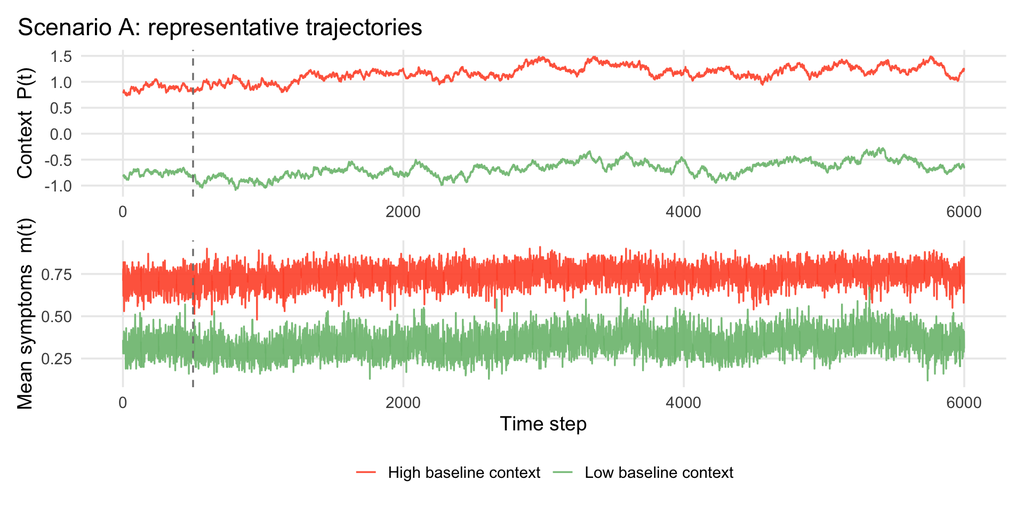

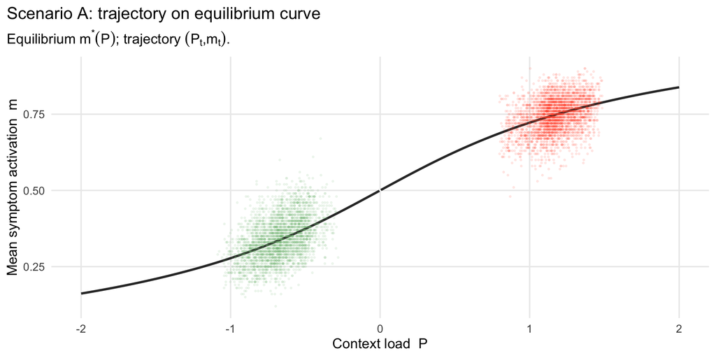

```r
burn_in= 500

# palette & labels chosen once
pal <- c("Low baseline context"="#7ABD7D", "High baseline context"="#FF5733")

# pick representative reps (per group)
rep_pick_A <- pick_representative_reps(res_A$metrics)

sim_A_rep <- res_A$sim_all %>%
  dplyr::inner_join(rep_pick_A, by = c("group","rep"))

p_ts_A <- plot_timeseries_with_folds(
  sim_df = sim_A_rep,
  folds = res_A$bif_info,     # ok even if folds NA
  title = "Scenario A: representative trajectories",
  burn_in = 500,
  show_burn = TRUE,
  cols = pal,
  base_size = 14
)

p_ov_A <- plot_branch_overlay(
  bf = res_A$bf,
  bif_info = res_A$bif_info,
  sim_df = sim_A_rep,
  title = "Scenario A: trajectory on equilibrium curve",
  burn_in = 500,
  cols = pal,
  ribbon_alpha = 0.0,         # A is monostable; no ribbon needed
  base_size = 14
)

p_ts_A; p_ov_A
```

> Scenario A is the control case: $βJ<4$, so the fast layer has a single stable equilibrium $m^∗(P)$ for every context level $P$.  
> Groups differ only in the baseline context $P_{base}$; realized $P_t$ then fluctuates around it (and can shift a bit due to feedback $b>0$).  
> As expected, the context trajectories separate smoothly, and the symptom mean $m_t$ follows smoothly as well—no jumps, no hysteresis, no regime switching.

> Each dot is one time step: the system’s context $P_t$ on the x-axis and the observed mean symptom activation $m_t$ on the y-axis.  
> The black curve is the mean-field equilibrium $m^∗(P)$, the unique stable mapping in Scenario A since $βJ<4$.  
> The two groups differ only in baseline context, so they occupy different regions of $P$, and therefore different regions of $m$, but they follow the same underlying curve.  
> The cloudiness around the curve is finite-size and stochastic update noise. The key point is: monostability gives smooth context → smooth symptom differences.

## *Scenario B*: hysteresis under a slow context ramp (no feedback)

**Goal**: demonstrate path dependence when the fast layer is bistable-capable ($βJ>4$), even when context is purely exogenous.

**Mechanism**: set feedback off ($b=0$) and impose a slow up–down ramp in the baseline context $P_{base}(t)$. As $P_{base}(t)$ rises, the system tends to track the low-symptom branch until it loses stability and jumps high; when the ramp decreases, it remains high until the opposite threshold is crossed. Plotting $m$ vs $P$ reveals a hysteresis loop (same $P$, different $m$, depending on history).

Here we use the same bistable fast layer for B and C:

```r
par_fast_BC <- list(
  n_nodes = 100,
  sweeps  = 40,
  beta    = beta_BC,
  J       = J_BC,
  h0      = h0_BC,
  gammaP  = gammaP_BC
)
```

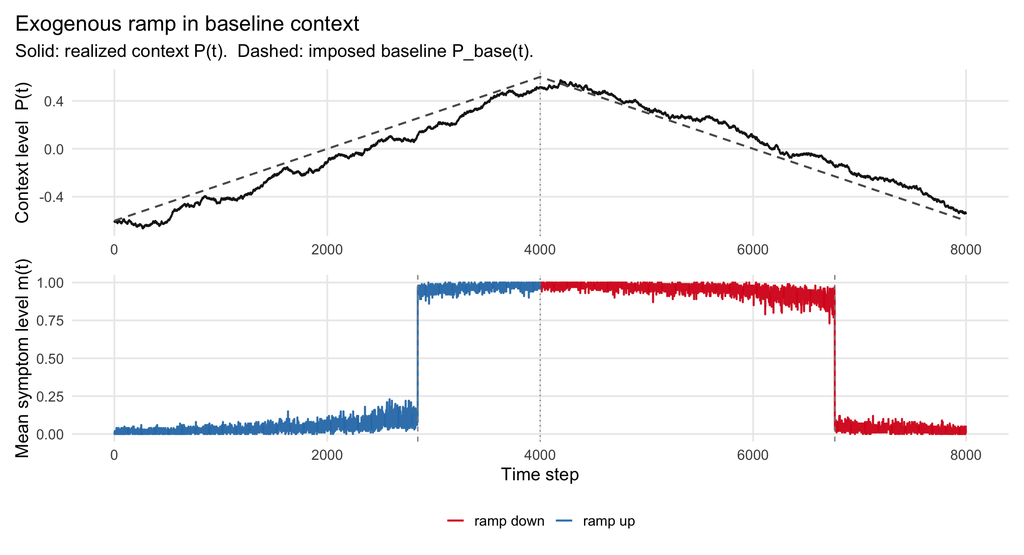

```r
Pbase_fun <- make_ramp_Pbase(
  T_steps = 8000,
  Pmin = -0.6,
  Pmax =  0.6,
  frac_up = 0.5
)

par_slow_B2 <- list(
  dt       = 0.02,
  kappa    = 0.15,   # allow P to track the ramp (not too stiff)
  b        = 0.00,   # no feedback
  m_star   = 0.30,
  sigmaP   = 0.02,   # low noise for clean hysteresis
  lambda_m = 0.001
)

# sim_B2 <- do.call(simulate_slowfast_cw01_timevaryingPbase, c(
#   list(
#     T_steps = 8000,
#     P_base_fun = Pbase_fun,
#     P0 = -0.6,
#     m0 = 0.05,
#     seed = 321
#   ),
#   par_fast_BC,
#   par_slow_B2
# ))

# saveRDS(sim_B2, "res/sim_B2.rds")
sim_B2 <- readRDS("res/sim_B2.rds")


# Make sure your Pbase_fun is deterministic (same ramp each time)
# and that simulate_slowfast_cw01_timevaryingPbase uses `seed` properly.
run_B2_reps_furrr <- function(
  n_rep = 30,
  seed_base = 9000,
  T_steps = 8000,
  Pbase_fun,
  P0 = -0.6,
  m0 = 0.05,
  par_fast = par_fast_BC,
  par_slow = par_slow_B2
) {
  seeds <- seed_base + seq_len(n_rep)

  furrr::future_map_dfr(
    seq_along(seeds),
    function(i) {
      seed_i <- seeds[i]

      sim <- do.call(simulate_slowfast_cw01_timevaryingPbase, c(
        list(
          T_steps = T_steps,
          P_base_fun = Pbase_fun,
          P0 = P0,
          m0 = m0,
          seed = seed_i
        ),
        par_fast,
        par_slow
      ))

      sim$rep <- i
      sim$seed <- seed_i
      sim
    },
    .options = furrr::furrr_options(seed = TRUE),
    .progress = TRUE
  )
}


# sim_B2_all <- run_B2_reps_furrr(
#   n_rep = 30,
#   seed_base = 9000,
#   T_steps = 8000,
#   Pbase_fun = Pbase_fun,
#   par_fast = par_fast_BC,
#   par_slow = par_slow_B2
# )

# saveRDS(sim_B2_all, "res/sim_B2_all.rds")
sim_B2_all <- readRDS("res/sim_B2_all.rds")


# --- colors (use consistent palette) ---
col_up   <- "#2C7BB6"  # ramp-up (blue)
col_down <- "#D7191C"  # ramp-down (red)
col_base <- "grey35"   # baseline P_base(t)
col_P    <- "grey10"   # realized P(t)

# --- label helper: ramp phase ---
T_steps <- max(sim_B2$t, na.rm = TRUE)
Tup <- floor(T_steps * 0.5)  # matches frac_up = 0.5

dfB <- sim_B2 %>%
  mutate(
    phase = if_else(t <= Tup, "ramp up", "ramp down")
  )

# --- detect jump times (simple heuristic) ---
# jumps happen when m changes abruptly; threshold can be tuned
jump_idx <- which(abs(diff(dfB$m)) > 0.4)
jump_t <- dfB$t[jump_idx + 1]

# also collect corresponding (P, m) points for markers on loop plot
jump_pts <- dfB %>%
  filter(t %in% jump_t) %>%
  select(t, P, m, phase)

base_theme <- theme_minimal(base_size = 15) +
  theme(
    plot.title.position = "plot",
    panel.grid.minor = element_blank(),
    legend.position = "bottom"
  )

# ---- Panel 1: P(t) + P_base(t) ----
pP <- ggplot(dfB, aes(x = t)) +
  geom_line(aes(y = P), linewidth = 0.8, colour = col_P) +
  geom_line(aes(y = P_base), linewidth = 0.8, linetype = "dashed", colour = col_base) +
  geom_vline(xintercept = Tup, linetype = "dotted", colour = "grey55") +
  labs(
    title = "Exogenous ramp in baseline context",
    subtitle = "Solid: realized context P(t).  Dashed: imposed baseline P_base(t).",
    x = NULL,
    y = "Context level  P(t)"
  ) +
  base_theme

# ---- Panel 2: m(t), colored by phase ----
pm <- ggplot(dfB, aes(x = t, y = m, colour = phase)) +
  geom_line(linewidth = 0.8, alpha = 0.95) +
  # optional: mark detected jumps
  geom_vline(xintercept = jump_t, linetype = "dashed", colour = "grey55", linewidth = 0.5) +
  geom_vline(xintercept = Tup, linetype = "dotted", colour = "grey55") +
  scale_colour_manual(values = c("ramp up" = col_up, "ramp down" = col_down)) +
  labs(
    x = "Time step",
    y = "Mean symptom level m(t)",
    colour = NULL
  ) +
  base_theme

# ---- Panel 3: hysteresis loop in (P, m) ----
ploop <- ggplot(dfB, aes(x = P, y = m, colour = phase)) +
  geom_path(linewidth = 0.8, alpha = 0.7) +
  # optional: highlight jump points
  geom_point(data = jump_pts, aes(P, m), size = 2.4, stroke = 0.6) +
  scale_colour_manual(values = c("ramp up" = col_up, "ramp down" = col_down)) +
  labs(
    title = "Hysteresis loop in (P, m)",
    subtitle = "Same P can map to different m depending on whether context is rising or falling.",
    x = "Context  P",
    y = "Mean symptoms  m",
    colour = NULL
  ) +
  base_theme

# ---- Stack them ----
pP / pm #/ ploop
```

[figure not shown]

*Takeaway*: With two stable modes, the system can stay on the high-symptom branch over a wide range of $P$; switching happens only when the ramp pushes $P$ past the branch limits, creating a loop in $(P,m)$. Clinically, worsening and recovery follow different thresholds: symptoms can remain elevated even after context improves, until improvement is strong enough to cross a lower recovery threshold.

## *Scenario C*: endogenous context (feedback) + rare shocks → capture vs switching

**Goal.** Scenario C shows what changes once *context is no longer purely imposed*. Context evolves endogenously via symptom-to-context feedback, and—optionally—experiences discrete adverse shocks. In a bistable fast layer, this produces two qualitatively different trajectories:

- **C1 (capture / lock-in):** once the trajectory reaches the high-symptom branch, feedback pushes context upward enough that the high state becomes self-sustaining (long dwell, few switches).
- **C2 (switching / episodic):** feedback is weaker and/or stochastic forcing is stronger, so the system repeatedly transitions between low and high modes (many switches, moderate dwell).

**Mechanism**: bistability + slow feedback

The fast layer is bistable-capable ($\beta J>4$), so for a range of context values $P$ there are two stable symptom equilibria (low and high). The slow context process includes feedback:

$$P_{t+1}=P_t + dt\Big[-\kappa(P_t-P_{\text{base}})+b(m_{\text{slow},t}-m_*)\Big]
+ \sigma_t\sqrt{dt}\varepsilon_t
+\text{shock}^{(\text{exo})}_t+\text{shock}^{(\text{endo})}_t,
\qquad \varepsilon_t\sim\mathcal N(0,1).$$

When symptoms are persistently high ($m_{\text{slow}}>m_*$), the feedback term shifts $P$ upward, stabilizing the high-symptom branch. With shocks enabled, rare adverse jumps can precipitate transitions, and symptom-triggered shocks can create a *self-reinforcing trap*.

**Optional shock mechanisms** (implemented as jump terms in $P_t$)

To model rare acute events as discontinuous changes in context, we optionally add jump shocks:

- **Exogenous shocks (C-exo):** occur independently of symptoms with constant intensity $\lambda_{\text{exo}}$ per unit time, converted to a per-step probability $1-e^{-\lambda_{\text{exo}}dt}$, with a cooldown to avoid unrealistic clustering.
- **Endogenous shocks (C-endo):** shock intensity increases with a *latent strain* variable that accumulates when $m_{\text{slow}}$ exceeds a threshold $m_{\text{crit}}$. Strain drives a *capped* time-varying hazard $\lambda_t=\min(\lambda_0+\lambda_1\text{strain}_t,\lambda_{\text{cap}})$, again converted to per-step probability $1-e^{-\lambda_t dt}$, with cooldown (and post-shock strain reduction) to prevent near-deterministic cascades.

**What is held fixed vs what varies in Scenario C**

**Held fixed (shared across all C subscenarios)**

- Fast-layer parameters $(\beta,J,h_0,\gamma_P)$ (bistable geometry)
- Group baselines $P_{\text{base}}$ (unless explicitly stated otherwise)

**Varied within Scenario C**

- Feedback / recovery balance: $(\kappa,b,m_*)$
- Continuous stochasticity: $\sigma_P$ (and optionally $\sigma_t$ if you use symptom-dependent volatility)
- *Shocks (optional):*
  - Exogenous intensity $\lambda_{\text{exo}}$ and amplitude $(\mu_{\text{exo}},\sigma_{\text{exo}})$, plus cooldown
  - Endogenous strain dynamics ($\rho_{\text{strain}}, m_{\text{crit}}$), hazard parameters ($\lambda_0,\lambda_1,\lambda_{\text{cap}}$), amplitude ($\mu_{\text{endo}},\sigma_{\text{endo}}$), plus cooldown / jitter and post-shock strain drop

#### C0. Shared setup: bistable fast layer + baseline groups

```r
# ---------------------------
# Scenario C0: shared definitions for all C variants
# ---------------------------

scen_C0 <- list(
  name   = "C",
  burn_in = 500,
  T_steps = 6000,
  n_rep   = 30,

  # Bistable-capable fast layer (shared across C1/C2 and shock variants)
  par_fast = list(
    n_nodes = 100,
    sweeps  = 40,
    beta    = beta_BC,
    J       = J_BC,
    h0      = h0_BC,
    gammaP  = gammaP_BC
  ),

  # Two baseline-context groups
  # - group 1 sits safely left of the bistable window
  # - group 2 sits near/inside the window, so it can access both branches
  groups = tibble::tibble(
    group  = c("Low baseline context", "High baseline context"),
    P_base = c(P_low_fold - 0.8, 0.0)
  )
)

# convenience vectors (used by run_scenario_diagnostics_v2)
labels_C  <- scen_C0$groups$group
P_bases_C <- scen_C0$groups$P_base
par_fast_C <- scen_C0$par_fast
```

> We place the **low-baseline** group well to the left of the bistable window $[P_{\text{low fold}}, P_{\text{high fold}}]$, so it stays on the low branch. We place the **high-baseline** group near $P\approx 0$, close to/inside the bistable window, so noise and feedback can move it between branches.

#### C1–C2. Feedback only (no jump shocks): capture vs switching

Here we isolate the **endogenous feedback mechanism** by leaving shocks off (`shock_mode="none"`). We keep the fast layer fixed and choose two slow-layer parameterizations that yield clean examples of:

- **C1:** feedback-driven capture (lock-in on high branch)
- **C2:** feedback-driven switching (repeated transitions)

##### Select C1 / C2 parameter sets (grid-search)

Why search at all? In C, the regime (“capture” vs “switching”) depends on a balance: restoring force $\kappa$ vs feedback $b$ vs noise $\sigma_P$. Rather than hand-tuning, we do a small grid search, score candidates using switching/dwell summaries, and keep one representative parameter set for each regime.

```r
# Build cache once
cache_BC <- make_diag_cache(par_fast_BC, P_grid = seq(-2, 2, length.out = 250))

# ---- C1 search (capture) ----
grid_C1 <- tidyr::crossing(
  kappa = c(0.10, 0.16),
  b     = c(0.28, 0.36),
  sigmaP= c(0.03, 0.06),
  m_star= c(0.12, 0.18)
)

cand_C1 <- grid_search_C(
  par_fast = par_fast_BC, P_bases = P_bases_C, labels = labels_C,
  grid = grid_C1, cache = cache_BC, scenario_prefix = "C1-cand",
  T_steps = 2000, n_rep = 4, burn_in = 200, seed_base = 6000
)

best_C1 <- cand_C1 |>
  dplyr::rowwise() |>
  dplyr::mutate(score = score_C1(dplyr::pick(dplyr::everything()))) |>
  dplyr::ungroup() |>
  dplyr::arrange(dplyr::desc(score)) |>
  dplyr::slice(1)

# saveRDS(best_C1, "res/best_C1_v2.rds")


# ---- C2 search (switching) ----
grid_C2 <- tidyr::crossing(
  kappa = c(0.22, 0.30, 0.38),
  b     = c(0.10, 0.16, 0.20),
  sigmaP= c(0.10, 0.16, 0.20),
  m_star= c(0.25)
)

cand_C2 <- grid_search_C(
  par_fast = par_fast_BC, P_bases = P_bases_C, labels = labels_C,
  grid = grid_C2, cache = cache_BC, scenario_prefix = "C2-cand",
  T_steps = 2000, n_rep = 4, burn_in = 200, seed_base = 8000
)

best_C2 <- cand_C2 |>
  dplyr::rowwise() |>
  dplyr::mutate(score = score_C2(dplyr::pick(dplyr::everything()))) |>
  dplyr::ungroup() |>
  dplyr::arrange(dplyr::desc(score)) |>
  dplyr::slice(1)

# saveRDS(best_C2, "res/best_C2_v2.rds")
```

```r
# ---------------------------
# Scenario C0: shared setup
# ---------------------------
scen_C0 <- list(
  burn_in = 500,
  T_steps = 6000,
  n_rep   = 30,
  groups = tibble::tibble(
    group  = c("Low baseline context", "High baseline context"),
    P_base = c(P_low_fold - 0.8, 0.0)
  ),
  par_fast = par_fast_BC   # <- already defined above (bistable-capable)
)

# ---------------------------
# Load grid-search picks (fixed, reproducible)
# ---------------------------
best_C1 <- readRDS("res/best_C1_v2.rds") |> dplyr::slice(1)
best_C2 <- readRDS("res/best_C2_v2.rds") |> dplyr::slice(1)


# ---------------------------
# Scenario C1/C2: finalize slow params (NO SHOCKS)
# ---------------------------
scen_C1 <- list(
  name      = "C1 (feedback only): capture",
  seed_base = 12000,
  par_fast  = scen_C0$par_fast,
  groups    = scen_C0$groups,
  par_slow  = list(
    dt       = 0.02,
    kappa    = best_C1$kappa[[1]],
    b        = best_C1$b[[1]],
    sigmaP   = best_C1$sigmaP[[1]],
    m_star   = best_C1$m_star[[1]],
    lambda_m = 0.001,
    shock_mode = "none"   # explicit baseline: no jumps
  )
)

scen_C2 <- list(
  name      = "C2 (feedback only): switching",
  seed_base = 15000,
  par_fast  = scen_C0$par_fast,
  groups    = scen_C0$groups,
  par_slow  = list(
    dt       = 0.02,
    kappa    = best_C2$kappa[[1]],
    b        = best_C2$b[[1]],
    sigmaP   = best_C2$sigmaP[[1]],
    m_star   = best_C2$m_star[[1]],
    lambda_m = 0.001,
    shock_mode = "none"
  )
)

# convenience (same as A)
labels_C  <- scen_C0$groups$group
P_bases_C <- scen_C0$groups$P_base
```

```r
# res_C1 <- run_scenario_diagnostics_v2(
#   scenario_name = scen_C1$name,
#   par_fast  = scen_C1$par_fast,
#   par_slow  = scen_C1$par_slow,
#   P_bases   = P_bases_C,
#   labels    = labels_C,
#   T_steps   = scen_C0$T_steps,
#   n_rep     = scen_C0$n_rep,
#   seed_base = scen_C1$seed_base,
#   burn_in   = scen_C0$burn_in,
#   parallel  = TRUE
# )
# saveRDS(res_C1, "res/res_C1_v3.rds")
res_C1 <- readRDS("res/res_C1_v3.rds")

# res_C2 <- run_scenario_diagnostics_v2(
#   scenario_name = scen_C2$name,
#   par_fast  = scen_C2$par_fast,
#   par_slow  = scen_C2$par_slow,
#   P_bases   = P_bases_C,
#   labels    = labels_C,
#   T_steps   = scen_C0$T_steps,
#   n_rep     = scen_C0$n_rep,
#   seed_base = scen_C2$seed_base,
#   burn_in   = scen_C0$burn_in,
#   parallel  = TRUE
# )
# saveRDS(res_C2, "res/res_C2_v3.rds")
res_C2 <- readRDS("res/res_C2_v3.rds")
```

```r
pick_representative_reps <- function(metrics_df){
  metrics_df |>
    dplyr::group_by(scenario, group) |>
    dplyr::mutate(target = mean(mean_m, na.rm = TRUE)) |>
    dplyr::slice_min(abs(mean_m - target), n = 1, with_ties = FALSE) |>
    dplyr::ungroup() |>
    dplyr::select(scenario, group, rep)
}

# common settings
burn_in <- 500
pal <- c("Low baseline context"="#7ABD7D", "High baseline context"="#FF5733")
```

```r
ms_C1_talk <- res_C1$metrics_summary |>
  dplyr::transmute(
    Group               = group,
    `Mean context E[P_t]`    = round(mean_P, 3),
    `Mean symptoms E[m_t]`   = round(mean_m, 3),
    `Pr(m_t > 0.5)`          = round(frac_high_abs, 3),
    `Switches (branch)`      = round(n_switch, 1),
    `Median high dwell`      = round(med_high_dwell, 1)
  )

knitr::kable(
  ms_C1_talk,
  align = "lrrrrr",
  caption = "Scenario C1 summary (bistable + feedback: capture / lock-in)."
) |>
  kableExtra::kable_styling(full_width = TRUE,
                            bootstrap_options = c("striped","condensed")) |>
  kableExtra::row_spec(0, bold = TRUE)
```

Scenario C1 summary (bistable + feedback: capture / lock-in).

| Group | Mean context E[P_t] | Mean symptoms E[m_t] | Pr(m_t > 0.5) | Switches (branch) | Median high dwell |
| --- | --- | --- | --- | --- | --- |
| High baseline context | 0.456 | 0.374 | 0.349 | 4.5 | 1 |
| Low baseline context | -1.290 | 0.004 | 0.000 | 0.0 | NA |

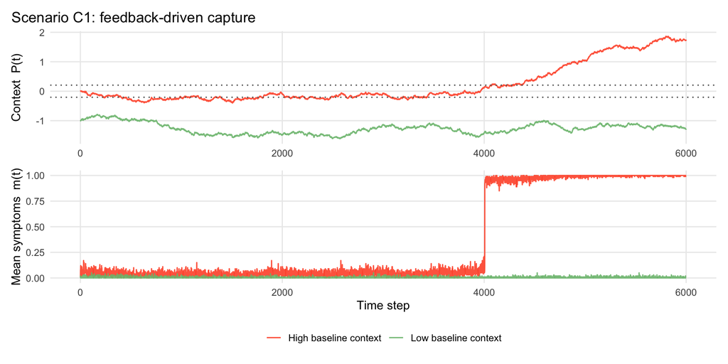

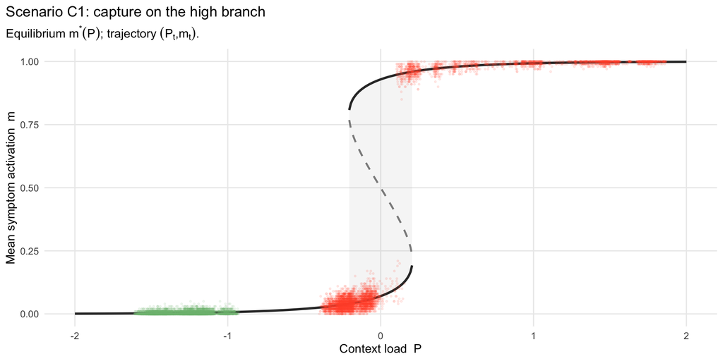

```r
# ---- C1 ----
rep_pick_C1 <- pick_representative_reps(res_C1$metrics)

sim_C1_rep <- res_C1$sim_all |>
  dplyr::inner_join(rep_pick_C1, by = c("group","rep"))

p_ts_C1 <- plot_timeseries_with_folds(
  sim_df  = sim_C1_rep,
  folds   = res_C1$bif_info,
  title   = "Scenario C1: feedback-driven capture",
  burn_in = burn_in,
  cols    = pal
)

p_ov_C1 <- plot_branch_overlay(
  bf       = res_C1$bf,
  bif_info = res_C1$bif_info,
  sim_df   = sim_C1_rep,
  title    = "Scenario C1: capture on the high branch",
  burn_in  = burn_in,
  cols     = pal,
  ribbon_alpha = 0.12,
  max_points_per_group = 6000
)

p_ts_C1; p_ov_C1
```

- **Top time-series panel** $P(t)$: The “high baseline context” group starts near $P \approx 0$, then **drifts upward over time**. That drift is not imposed (unlike Scenario B). It is generated by **feedback** from symptoms: when $m_{\text{slow}}$ rises above $m_*$, the drift term $b(m_{\text{slow}}-m_*)$ pushes $P$ upward.
  - The lower-baseline group stays around a clearly negative context region the entire time.
  - The higher-baseline group starts near the bistable window and then shows an endogenous upward drift in context.
  - Crucially, this is not imposed (unlike Scenario B). In C1, context is partly generated by symptoms through feedback $b>0$.
- **Middle time-series panel** $m(t)$: The higher-baseline group low for a while, then **jumps sharply** to $m \approx 1$ and remains there. This is the “capture” event (i.e., *locking-in*): once it hits the high-symptom basin, the feedback raises $P$ enough that the high basin remains self-supported.
- **Bottom** $m$ vs $P$ overlay (bifurcation diagram):
  - The black curves are the mean-field equilibria $m^*(P)$ (stable branches), the dashed curve is unstable, and the grey band is the bistable window.
  - The dots show the system’s visited $(P_t, m_t)$ pairs.
  - The trajectory for the higher-baseline group:
    1. enters the **bistable window** near $P\approx 0$, still on the low branch,
    2. then flips up to the high branch,
    3. and subsequently “moves rightward” to larger $P$ because feedback keeps pushing context upward.
- That “move right and stay high” is the visual fingerprint of a **self-reinforcing loop**:
  $$\text{high } m \Rightarrow \text{pushes } P \uparrow \Rightarrow \text{stabilizes high } m$$

```r
ms_C2_talk <- res_C2$metrics_summary |>
  dplyr::mutate(
    Group = dplyr::case_when(
      group == "Lower baseline context"  ~ "Low precarity",
      group == "Higher baseline context" ~ "High precarity",
      TRUE ~ group
    )
  ) |>
  dplyr::transmute(
    Group,
    `Mean context E[P_t]`    = round(mean_P, 3),
    `Mean symptoms E[m_t]`   = round(mean_m, 3),
    `Pr(m_t > 0.5)`          = round(frac_high_abs, 3),
    `Switches (branch)`      = round(n_switch, 1),
    `Median high dwell`      = round(med_high_dwell, 1)
  )

knitr::kable(
  ms_C2_talk,
  align = "lrrrrr",
  caption = "Scenario C2 summary (bistable + feedback: frequent switching)."
) |>
  kableExtra::kable_styling(full_width = TRUE,
                            bootstrap_options = c("striped","condensed")) |>
  kableExtra::row_spec(0, bold = TRUE)
```

Scenario C2 summary (bistable + feedback: frequent switching).

| Group | Mean context E[P_t] | Mean symptoms E[m_t] | Pr(m_t > 0.5) | Switches (branch) | Median high dwell |
| --- | --- | --- | --- | --- | --- |
| High baseline context | 0.158 | 0.723 | 0.74 | 16.3 | 161 |
| Low baseline context | -1.097 | 0.006 | 0.00 | 0.0 | NA |

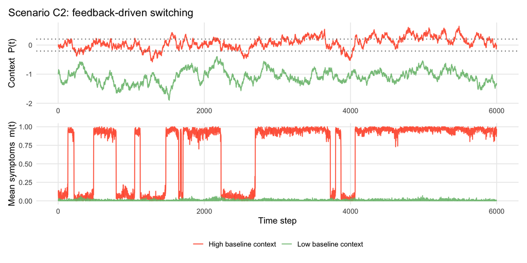

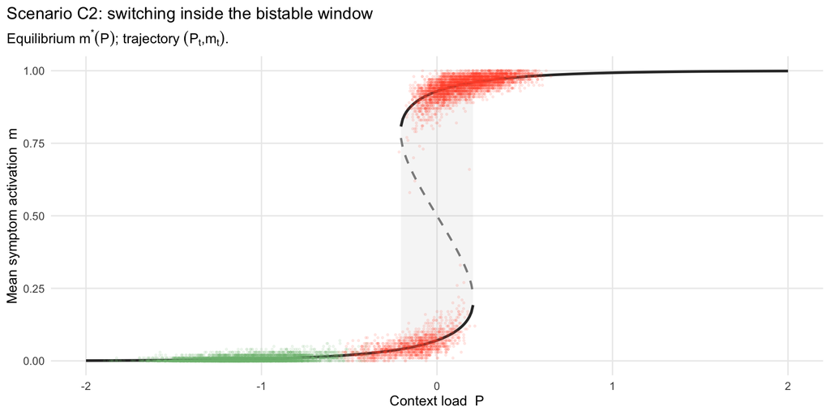

```r
# ---- C2 ----
rep_pick_C2 <- pick_representative_reps(res_C2$metrics)

sim_C2_rep <- res_C2$sim_all |>
  dplyr::inner_join(rep_pick_C2, by = c("group","rep"))

p_ts_C2 <- plot_timeseries_with_folds(
  sim_df  = sim_C2_rep,
  folds   = res_C2$bif_info,
  title   = "Scenario C2: feedback-driven switching",
  burn_in = burn_in,
  cols    = pal
)

p_ov_C2 <- plot_branch_overlay(
  bf       = res_C2$bf,
  bif_info = res_C2$bif_info,
  sim_df   = sim_C2_rep,
  title    = "Scenario C2: switching inside the bistable window",
  burn_in  = burn_in,
  cols     = pal,
  ribbon_alpha = 0.12,
  max_points_per_group = 6000
)

p_ts_C2; p_ov_C2
```

- **Top panel: context** $P(t)$
  - The higher-baseline group wanders **within/near the bistable window** but does **not** drift monotonically upward the way C1 does.
  - Noise + weaker/less stabilizing feedback means the system keeps being perturbed back and forth across the region where both modes are possible.
- **Middle panel: symptoms** $m(t)$
  - The higher-baseline group shows **repeated episodes** of being high and then returning low: many switches.
  - The lower-baseline group remains low and does not enter the switching region (consistent with your summary table: switches ~0, Pr(m>0.5)=0).
- **Bottom panel: bifurcation diagram**
  - The higher-baseline group’s points populate both the low and high branches **inside the bistable window**.
  - The frequent vertical transitions in the overlay correspond to the time-series switching events.
  - The key distinction vs C1 is **lack of permanent “locking-in”**: it can visit the high mode but does not get trapped there long-term.

*Takeaway*: C2 shows *episodic instability*; the system repeatedly toggles between low and high symptom modes because feedback isn’t strong enough to lock the trajectory onto one branch.

#### C-S. Shocks as a stress-test layer (rare adverse events)

The feedback-only C1/C2 cases establish the baseline dynamics with **no jumps**. We now add *rare discrete shocks* to the context process, implemented in `simulate_slowfast_cw01_v2()` as additive jump terms `shock_exo[t]` and/or `shock_endo[t]` in the update of $P_{t+1}$.

We use shocks for two extensions:

To keep shocks “rare” at the simulation time-scale, we (i) keep hazards small, and (ii) impose a **cooldown** (refractory period) after each shock to prevent unrealistic clustering.

#### C-S. Shocks as a stress-test layer (rare adverse events)

The feedback-only C1/C2 is the clean dynamical baseline. We then add discrete shocks to show two clinically interpretable extensions:

1. **C-exo:** groups differ in *exogenous shock exposure* (same dynamics otherwise)
2. **C-endo:** shocks become *symptom-triggered* (endogenous hazard), creating a trap mechanism

We keep shocks **rare** (via low hazard and/or cooldown) to avoid “job-loss every week” dynamics.

#### C-exo: group differences driven by exposure (different $\lambda_{\text{exo}}$)

*Idea.* Keep the *same* dynamical system, but let groups differ in the rate of independent adverse events. This yields different switching rates and time-in-state without changing coupling.

```r
# ---------------------------
# Scenario C-S: shocks as stress-test variants
# Base: start from C2 slow params, then add shocks
# ---------------------------

# A helper: “copy C2 and tweak slow params”
make_C_variant <- function(name, seed_base, par_slow_mod, groups_mod = NULL) {
  out <- scen_C2
  out$name      <- name
  out$seed_base <- seed_base

  # optionally override groups/P_base if the variant needs different starting context
  if (!is.null(groups_mod)) out$groups <- groups_mod

  # modify slow params
  out$par_slow <- modifyList(out$par_slow, par_slow_mod)

  out
}

# convenience labels (match A approach)
labels_Cs  <- scen_C0$groups$group
P_bases_Cs <- scen_C0$groups$P_base
```

```r
# ---------------------------
# C-exo: same dynamics, different exogenous exposure by group
# ---------------------------

# (A) Base slow dynamics for this stress-test
# Make the baseline (no-shock) process relatively stable so shocks "do the work"
par_slow_exo_base <- modifyList(scen_C2$par_slow, list(
  sigmaP     = 0.05,   # reduce continuous noise vs C2
  kappa      = 0.235,  # stronger reversion to P_base
  b          = 0.10,   # keep small (set to 0 for pure exposure)
  shock_mode = "exo"   # enable exogenous jump shocks
))

# (B) Group-specific exogenous shock exposure
# IMPORTANT: lambda_exo is intensity per unit time; per-step prob is 1-exp(-lambda_exo*dt)
par_slow_exo_by_group <- list(
  "Low baseline context"  = modifyList(par_slow_exo_base, list(
    lambda_exo   = 0.010,  # lower exposure
    shock_mu_exo = 0.50,   # mean jump size (adds to P)
    shock_sd_exo = 0.15,   # variability of jump size
    cooldown_exo = 150     # refractory period (steps) after a shock
  )),
  "High baseline context" = modifyList(par_slow_exo_base, list(
    lambda_exo   = 0.020,  # higher exposure
    shock_mu_exo = 0.50,
    shock_sd_exo = 0.15,
    cooldown_exo = 150
  ))
)

# (C) Optional: choose starting baselines for this demonstration
# Both groups start "low-ish", but one is closer to the bistable window (more vulnerable to kicks)
groups_C_exo <- tibble::tibble(
  group  = c("Lower baseline context", "Higher baseline context"),
  P_base = c(-0.6, -0.2)
)

# (D) Bundle as a scenario object (same style as A/C1/C2)
scen_C_exo <- list(
  name      = "C-exo: group-differential exogenous shocks",
  seed_base = 18000,
  burn_in   = scen_C0$burn_in,
  T_steps   = scen_C0$T_steps,
  n_rep     = scen_C0$n_rep,
  par_fast  = scen_C0$par_fast,
  groups    = groups_C_exo,
  par_slow  = par_slow_exo_by_group
)

# (E) Run or load
# res_C_exo <- run_scenario_diagnostics_v2(
#   scenario_name = scen_C_exo$name,
#   par_fast  = scen_C_exo$par_fast,
#   par_slow  = scen_C_exo$par_slow,         # named list by group
#   P_bases   = scen_C_exo$groups$P_base,
#   labels    = scen_C_exo$groups$group,
#   T_steps   = scen_C_exo$T_steps,
#   n_rep     = scen_C_exo$n_rep,
#   seed_base = scen_C_exo$seed_base,
#   burn_in   = scen_C_exo$burn_in,
#   parallel  = TRUE
# )
# saveRDS(res_C_exo, "res/res_C_exo.rds")
res_C_exo <- readRDS("res/res_C_exo.rds")

# (F) Summary table (A-style: simple, no recode splicing issues)
ms_C_exo_talk <- res_C_exo$metrics_summary |>
  dplyr::transmute(
    Group            = group,
    `Mean context E[P]`  = round(mean_P, 3),
    `Mean symptoms E[m]` = round(mean_m, 3),
    `Pr(m>0.5)`          = round(frac_high_abs, 3),
    `Switches`           = round(n_switch, 2),
    `Mean shocks`        = round(n_shock, 2)
  )

knitr::kable(
  ms_C_exo_talk,
  align = "lrrrrr",
  caption = "Scenario C-exo summary (same dynamics; group differences only in exogenous shock exposure)."
) |>
  kableExtra::kable_styling(full_width = TRUE, bootstrap_options = c("striped","condensed")) |>
  kableExtra::row_spec(0, bold = TRUE)
```

| Group | Mean context E[P] | Mean symptoms E[m] | Pr(m>0.5) | Switches | Mean shocks |
| --- | --- | --- | --- | --- | --- |
| Higher baseline context | -0.175 | 0.218 | 0.199 | 10.30 | 2.67 |
| Lower baseline context | -0.671 | 0.015 | 0.000 | 0.13 | 1.23 |

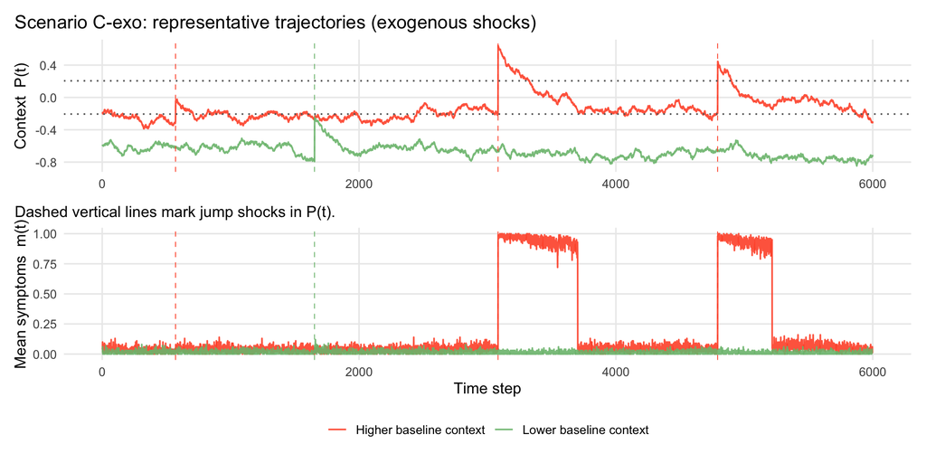

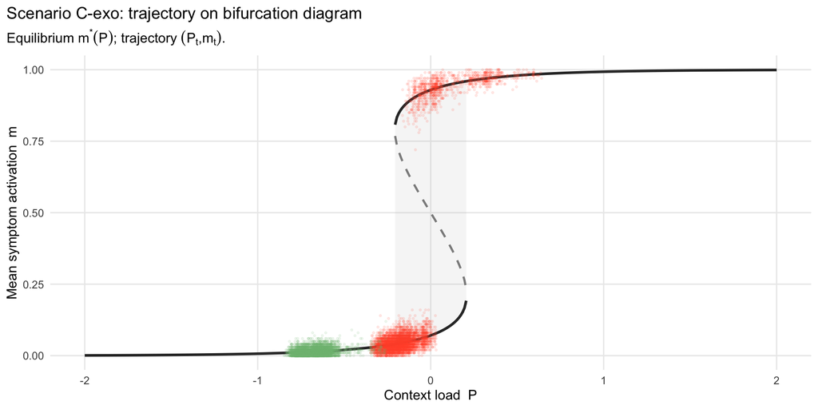

```r
pal2 <- c(
  "Lower baseline context"  = "#7ABD7D",
  "Higher baseline context" = "#FF5733"
)

# 1) representative reps (per group)
rep_pick_Cexo <- pick_representative_reps(res_C_exo$metrics)

# 2) representative trajectories
sim_Cexo_rep <- res_C_exo$sim_all |>
  dplyr::inner_join(rep_pick_Cexo, by = c("group", "rep"))

# 3) base time series (from utils)
p_ts_Cexo <- plot_timeseries_with_folds(
  sim_df    = sim_Cexo_rep,
  folds     = res_C_exo$bif_info,
  title     = "Scenario C-exo: representative trajectories (exogenous shocks)",
  burn_in   = burn_in,
  show_burn = FALSE,
  cols      = pal2
)

# 4) shock times by group (new unified helper)
p_ts_Cexo <- plot_timeseries_with_folds(
  sim_df      = sim_Cexo_rep,
  folds       = res_C_exo$bif_info,
  title       = "Scenario C-exo: representative trajectories (exogenous shocks)",
  burn_in     = burn_in,
  show_burn   = FALSE,
  cols        = pal2,
  show_shocks = TRUE,
  shocks_by_group = TRUE
)




# 5) bifurcation overlay (unchanged)
p_ov_Cexo <- plot_branch_overlay(
  bf       = res_C_exo$bf,
  bif_info = res_C_exo$bif_info,
  sim_df   = sim_Cexo_rep,
  title    = "Scenario C-exo: trajectory on bifurcation diagram",
  burn_in  = burn_in,
  cols     = pal2,
  ribbon_alpha = 0.12,
  max_points_per_group = 6000
)

p_ts_Cexo; p_ov_Cexo
```